# R_Assignment_Code

Zhanyi

2025-03-12

# R Assignment Zhanyi Yao

## Analysis Preparation

Before the analysis, I cleared the workspace and loaded the libraries needed first.

```r
rm(list = ls())
library(tidyr)
library(tidyverse)
```

## Data Inspection

### Inspection of ‘fang_et_al_genotypes.txt’

Load the data of fang_et_al_genotypes.txt for inspection.

```r
file_path <- "fang_et_al_genotypes.txt"
data <- read_delim(file_path, delim="\t")
```

Check the size of fang_et_al_genotypes.txt in MB.

```r
file_size <- file.info(file_path)[1,1]/1000000
print(file_size)
```

```
## [1] 11.05194
```

Check the data frame dimensions of fang_et_al_genotypes.txt, returning # of rows and columns.

```r
dim(data)
```

```
## [1] 2782  986
```

Check the first and last few rows of fang_et_al_genotypes.txt for metadata.

```r
head(data)
```

```
## # A tibble: 6 × 986
##   Sample_ID JG_OTU   Group abph1.20 abph1.22 ae1.3 ae1.4 ae1.5 an1.4 ba1.6 ba1.9
##   <chr>     <chr>    <chr> <chr>    <chr>    <chr> <chr> <chr> <chr> <chr> <chr>
## 1 SL-15     T-aust-1 TRIPS ?/?      ?/?      T/T   G/G   T/T   C/C   ?/?   G/G
## 2 SL-16     T-aust-2 TRIPS ?/?      ?/?      T/T   ?/?   T/T   C/C   A/G   G/G
## 3 SL-11     T-brav-1 TRIPS ?/?      ?/?      T/T   G/G   T/T   ?/?   G/G   G/G
## 4 SL-12     T-brav-2 TRIPS ?/?      ?/?      T/T   G/G   T/T   C/C   G/G   G/G
## 5 SL-18     T-cund   TRIPS ?/?      ?/?      T/T   G/G   T/T   C/C   ?/?   G/G
## 6 SL-2      T-dact-1 TRIPS ?/?      ?/?      T/T   G/G   T/T   C/C   A/G   G/G
## # ℹ 975 more variables: bt2.5 <chr>, bt2.7 <chr>, bt2.8 <chr>, Fea2.1 <chr>,
## #   Fea2.5 <chr>, id1.3 <chr>, lg2.11 <chr>, lg2.2 <chr>, pbf1.1 <chr>,
## #   pbf1.2 <chr>, pbf1.3 <chr>, pbf1.5 <chr>, pbf1.6 <chr>, pbf1.7 <chr>,
## #   pbf1.8 <chr>, PZA00003.11 <chr>, PZA00004.2 <chr>, PZA00005.8 <chr>,
## #   PZA00005.9 <chr>, PZA00006.13 <chr>, PZA00006.14 <chr>, PZA00008.1 <chr>,
## #   PZA00010.5 <chr>, PZA00013.10 <chr>, PZA00013.11 <chr>, PZA00013.9 <chr>,
## #   PZA00015.4 <chr>, PZA00017.1 <chr>, PZA00018.5 <chr>, PZA00029.11 <chr>, …
```

```r
tail(data)
```

```
## # A tibble: 6 × 986
##   Sample_ID JG_OTU   Group abph1.20 abph1.22 ae1.3 ae1.4 ae1.5 an1.4 ba1.6 ba1.9
##   <chr>     <chr>    <chr> <chr>    <chr>    <chr> <chr> <chr> <chr> <chr> <chr>
## 1 SYN262    Zmm-IL-… ZMMIL C/C      A/A      T/T   G/G   C/C   C/C   G/G   G/G
## 2 S0398     Zmm-IL-… ZMMIL G/G      A/A      T/T   G/G   C/C   C/C   G/G   G/G
## 3 S1636     Zmm-IL-… ZMMIL G/G      A/A      T/T   G/G   C/C   C/C   G/G   G/G
## 4 CU0201    Zmm-IL-… ZMMIL C/C      A/A      T/T   G/G   C/C   C/C   G/G   G/G
## 5 S0215     Zmm-IL-… ZMMIL G/G      A/A      T/T   ?/?   C/C   C/C   G/G   G/G
## 6 CU0202    Zmm-IL-… ZMMIL C/C      A/A      T/T   G/G   C/C   C/C   ?/?   G/G
## # ℹ 975 more variables: bt2.5 <chr>, bt2.7 <chr>, bt2.8 <chr>, Fea2.1 <chr>,
## #   Fea2.5 <chr>, id1.3 <chr>, lg2.11 <chr>, lg2.2 <chr>, pbf1.1 <chr>,
## #   pbf1.2 <chr>, pbf1.3 <chr>, pbf1.5 <chr>, pbf1.6 <chr>, pbf1.7 <chr>,
## #   pbf1.8 <chr>, PZA00003.11 <chr>, PZA00004.2 <chr>, PZA00005.8 <chr>,
## #   PZA00005.9 <chr>, PZA00006.13 <chr>, PZA00006.14 <chr>, PZA00008.1 <chr>,
## #   PZA00010.5 <chr>, PZA00013.10 <chr>, PZA00013.11 <chr>, PZA00013.9 <chr>,
## #   PZA00015.4 <chr>, PZA00017.1 <chr>, PZA00018.5 <chr>, PZA00029.11 <chr>, …
```

Check the last column of the rows loaded above.

```r
get_last_columns <- function(data, columns_to_return = 1) {
  last_column <- ncol(data)
  last_n_columns <- data.frame(data[,(last_column-columns_to_return+1):last_column])
  return(last_n_columns)
}
data_last_column_only <- get_last_columns(data)

head(data_last_column_only)
```

```
##   zmm3.4
## 1    T/T
## 2    T/T
## 3    T/T
## 4    T/T
## 5    T/T
## 6    T/T
```

```r
tail(data_last_column_only)
```

```
##      zmm3.4
## 2777    C/C
## 2778    C/C
## 2779    C/C
## 2780    C/C
## 2781    C/C
## 2782    C/C
```

Check the missing SNPs in fang_et_al_genotypes,txt.

```r
missing_count <- function(data) {
  length(grep("\\?",data))
}
SNP_missing_count <- sapply(data[,4:ncol(data)],missing_count)
SNP_missing<- sort(SNP_missing_count)
head(SNP_missing, n = 5)
```

```
## PZA00538.8 PZB00175.5 PZA00731.7 PZB00175.3 PZA00641.8
##          6          7          9         12         15
```

```r
tail(SNP_missing, n = 5)
```

```
##  PZA00315.6  PZA00047.2  PZD00073.1 PZA00307.17  PZB01223.4
##         440         447         449         487         509
```

Check the missing samples in fang_et_al_genotypes.txt.

```r
sample_missing_count <- apply(data,1,missing_count)
row_name <- unlist(data[,1],use.names = FALSE)
names(sample_missing_count) <- row_name
head(sample_missing_count, n=5)
```

```
## SL-15 SL-16 SL-11 SL-12 SL-18
##   332   345   241   268   317
```

```r
sample_missing_count[sample_missing_count == 0]
```

```
## named integer(0)
```

```r
sample_missing_count[sample_missing_count == max(sample_missing_count)]
```

```
## TAMex0516.1
##         398
```

```r
sample_missing_count[sample_missing_count == min(sample_missing_count)]
```

```
## DOE5H-1556
##          5
```

Check the five least and five most common groups of genes in fang_et_al_genotypes.txt.

```r
groups <- unlist(data[,3],use.names = FALSE)
common_groups<- sort(table(groups))
head(common_groups, n = 5)
```

```
## groups
## ZMXNT ZMXIL ZMXNO ZPERR ZMHUE
##     4     6     7     9    10
```

```r
tail(common_groups, n = 5)
```

```
## groups
## ZMXCP ZMXCH ZMMIL ZMPBA ZMMLR
##    69    75   290   900  1256
```

Conclusion of the Inspection of fang_et_al_genotypes.txt. - The file contains 2,783 lines and has a size of 11.06 MB. While the number of lines isn’t excessive, the file appears to have a relatively large number of words and characters. This is due to each line having multiple columns—one for each single nucleotide polymorphism (SNP) in the sample, along with some metadata. - Since the first line includes metadata with the header camp, and the tail contains no metadata, it seems that metadata is only present for the first row. This suggests that there are 2,782 samples in the SNP dataset. - Upon examining the number of columns, I found 986 in total. The first three columns contain metadata (sample ID, JG_OTU, and group), indicating that each sample has information on 983 SNPs. - Some SNPs are missing data, with instances of “?/?”. I couldn’t find any sample without a “?/?” for at least one SNP, so this seems to be quite common. - The SNP with the most missing data is PZB01223.4, with 509 samples missing data at that location. On the other hand, the SNP with the least missing data is PZA00538.8, missing data in only 6 samples. - The sample with the most missing data is TAMex0516.1, which has missing data for 398 SNPs, while DOE5H-1556 has the fewest, with only 5 SNPs missing data. - No duplicate gene types were found, though there were duplicate groups. The largest group was the ZMMLR group, with 1,256 members, while the smallest group was the ZMXNT group, with only 4 members.

### Inspection of ‘snp_position.txt’

Load the data of snp_position.txt for inspection.

```r
snp_path <- "snp_position.txt"
snp <- read_delim(snp_path, delim="\t")
```

Check the size of snp_position.txt in MB.

```r
snp_size <- file.info(snp_path)[1,1]/1000000
print(snp_size)
```

```
## [1] 0.082763
```

Check the data frame dimensions of snp_position.txt, returning # of rows and columns.

```r
dim(snp)
```

```
## [1] 983  15
```

Check the first and last few rows of snp_position.txt for metadata.

```r
head(snp)
```

```
## # A tibble: 6 × 15
##   SNP_ID   cdv_marker_id Chromosome Position  alt_pos mult_positions amplicon
##   <chr>            <dbl> <chr>      <chr>     <chr>   <chr>          <chr>
## 1 abph1.20          5976 2          27403404  <NA>    <NA>           abph1
## 2 abph1.22          5978 2          27403892  <NA>    <NA>           abph1
## 3 ae1.3             6605 5          167889790 <NA>    <NA>           ae1
## 4 ae1.4             6606 5          167889682 <NA>    <NA>           ae1
## 5 ae1.5             6607 5          167889821 <NA>    <NA>           ae1
## 6 an1.4             5982 1          240498509 <NA>    <NA>           an1
## # ℹ 8 more variables: cdv_map_feature.name <chr>, gene <chr>,
## #   `candidate/random` <chr>, Genaissance_daa_id <dbl>, Sequenom_daa_id <dbl>,
## #   count_amplicons <dbl>, count_cmf <dbl>, count_gene <dbl>
```

```r
tail(snp)
```

```
## # A tibble: 6 × 15
##   SNP_ID cdv_marker_id Chromosome Position  alt_pos mult_positions amplicon
##   <chr>          <dbl> <chr>      <chr>     <chr>   <chr>          <chr>
## 1 zap1.2          3514 2          233128584 <NA>    <NA>           zap1
## 2 zen1.1          3519 unknown    unknown   <NA>    <NA>           zen1
## 3 zen1.2          3520 unknown    unknown   <NA>    <NA>           zen1
## 4 zen1.4          3521 unknown    unknown   <NA>    <NA>           zen1
## 5 zfl2.6          6463 2          12543294  <NA>    <NA>           zfl2
## 6 zmm3.4          3527 9          16966348  <NA>    <NA>           zmm3
## # ℹ 8 more variables: cdv_map_feature.name <chr>, gene <chr>,
## #   `candidate/random` <chr>, Genaissance_daa_id <dbl>, Sequenom_daa_id <dbl>,
## #   count_amplicons <dbl>, count_cmf <dbl>, count_gene <dbl>
```

Check the last column of the rows loaded above.

```r
snp_last_column_only <- get_last_columns(snp)

head(snp_last_column_only)
```

```
##   count_gene
## 1          1
## 2          0
## 3          1
## 4          0
## 5          0
## 6          1
```

```r
tail(snp_last_column_only)
```

```
##     count_gene
## 978          1
## 979          1
## 980          0
## 981          0
## 982          1
## 983          1
```

Check the five least and most common chromosomes in snp_position.txt.

```r
chromosomes <- unlist(snp[,3],use.names = FALSE)
common_chromosomes<- sort(table(chromosomes))
head(common_chromosomes, n = 5)
```

```
## chromosomes
## multiple  unknown       10        9        8
##        6       27       53       60       62
```

```r
tail(common_chromosomes, n = 5)
```

```
## chromosomes
##   7   3   5   2   1
##  97 107 122 127 155
```

Check the five least and most common genes in snp_position.txt.

```r
genes <- unlist(snp[,9],use.names = FALSE)
common_genes<- sort(table(genes))
head(common_genes, n = 5)
```

```
## genes
##   AI622483        an1 ath-miR167 ath-miR394 ath-miR399
##          1          1          1          1          1
```

```r
tail(common_genes, n = 5)
```

```
## genes
## PZA03455      ra1     zag1 PZA03450    zmm28
##        8        8        8        9       11
```

Conclusion of the Inspection of snp_position.txt. - The file contains 984 lines and has a size of 83 KB, making it significantly smaller than the fang_et_al_genotypes.txt file, as expected. - The file doesn’t seem to include any metadata, with only the first line showing the column names. There are 15 columns in total, suggesting that the file documents 983 individual SNPs. - The chromosomes with the most SNPs are chromosome 1 (155 SNPs), chromosome 2 (127 SNPs), chromosome 5 (122 SNPs), chromosomes 3 (107 SNPs), and chromosome 7 (97 SNPs). Chromosome 10 has the fewest, with only 53 SNPs. - There are SNPs appear in multiple chromosomes or not defined. - The most common genes containing SNPs are zmm28 (11 SNPs), PZA03450 (9 SNPs), zag1 (8 SNPs), ra1 (8 SNPs), and PZA03455 (8 SNPs). I assume there will be more genes with 8 SNPs that are not listed.

## Data Processing

Process fang_el_at_genotypes.txt to obtain the desired columns in required format.

```r
extracted_data <- filter(data, `Group` %in% c("ZMMIL", "ZMMLR", "ZMMMR"))
extracted_data <- arrange(extracted_data, `Sample_ID`)
transposed_data <- as_tibble(t(extracted_data[,4:ncol(extracted_data)]),rownames = "SNP_ID")
colnames(transposed_data) <- c("SNP_ID",unlist(extracted_data[1:nrow(extracted_data),1]), use.names = FALSE)
head(extracted_data)
```

```
## # A tibble: 6 × 986
##   Sample_ID JG_OTU   Group abph1.20 abph1.22 ae1.3 ae1.4 ae1.5 an1.4 ba1.6 ba1.9
##   <chr>     <chr>    <chr> <chr>    <chr>    <chr> <chr> <chr> <chr> <chr> <chr>
## 1 BKN_001   Zmm-LR-… ZMMLR C/C      A/A      T/T   G/G   C/C   C/C   G/G   G/G
## 2 BKN_002   Zmm-LR-… ZMMLR C/C      A/A      T/T   G/G   C/C   C/C   G/G   G/G
## 3 BKN_003   Zmm-LR-… ZMMLR C/C      A/A      T/T   G/G   C/C   C/C   ?/?   G/G
## 4 BKN_004   Zmm-LR-… ZMMLR C/C      A/A      T/T   G/G   C/C   C/C   G/G   G/G
## 5 BKN_009   Zmm-MR2… ZMMMR C/C      A/A      T/T   G/G   T/T   C/C   G/G   G/G
## 6 BKN_010   Zmm-MR2… ZMMMR C/C      A/A      T/T   G/G   C/C   G/G   G/G   G/G
## # ℹ 975 more variables: bt2.5 <chr>, bt2.7 <chr>, bt2.8 <chr>, Fea2.1 <chr>,
## #   Fea2.5 <chr>, id1.3 <chr>, lg2.11 <chr>, lg2.2 <chr>, pbf1.1 <chr>,
## #   pbf1.2 <chr>, pbf1.3 <chr>, pbf1.5 <chr>, pbf1.6 <chr>, pbf1.7 <chr>,
## #   pbf1.8 <chr>, PZA00003.11 <chr>, PZA00004.2 <chr>, PZA00005.8 <chr>,
## #   PZA00005.9 <chr>, PZA00006.13 <chr>, PZA00006.14 <chr>, PZA00008.1 <chr>,
## #   PZA00010.5 <chr>, PZA00013.10 <chr>, PZA00013.11 <chr>, PZA00013.9 <chr>,
## #   PZA00015.4 <chr>, PZA00017.1 <chr>, PZA00018.5 <chr>, PZA00029.11 <chr>, …
```

```r
head(transposed_data)
```

```
## # A tibble: 6 × 1,574
##   SNP_ID BKN_001 BKN_002 BKN_003 BKN_004 BKN_009 BKN_010 BKN_011 BKN_012 BKN_013
##   <chr>  <chr>   <chr>   <chr>   <chr>   <chr>   <chr>   <chr>   <chr>   <chr>
## 1 abph1… C/C     C/C     C/C     C/C     C/C     C/C     C/C     ?/?     C/G
## 2 abph1… A/A     A/A     A/A     A/A     A/A     A/A     A/A     A/A     A/A
## 3 ae1.3  T/T     T/T     T/T     T/T     T/T     T/T     T/T     G/G     T/T
## 4 ae1.4  G/G     G/G     G/G     G/G     G/G     G/G     G/G     A/A     G/G
## 5 ae1.5  C/C     C/C     C/C     C/C     T/T     C/C     C/C     T/T     C/C
## 6 an1.4  C/C     C/C     C/C     C/C     C/C     G/G     C/C     C/C     C/C
## # ℹ 1,564 more variables: BKN_014 <chr>, BKN_015 <chr>, BKN_016 <chr>,
## #   BKN_017 <chr>, BKN_018 <chr>, BKN_019 <chr>, BKN_020 <chr>, BKN_021 <chr>,
## #   BKN_022 <chr>, BKN_023 <chr>, BKN_024 <chr>, BKN_025 <chr>, BKN_026 <chr>,
## #   BKN_027 <chr>, BKN_028 <chr>, BKN_029 <chr>, BKN_030 <chr>, BKN_031 <chr>,
## #   BKN_032 <chr>, BKN_033 <chr>, BKN_034 <chr>, BKN_035 <chr>, CU0001 <chr>,
## #   CU0002 <chr>, CU0003 <chr>, CU0004 <chr>, CU0005 <chr>, CU0006 <chr>,
## #   CU0007 <chr>, CU0008 <chr>, CU0009 <chr>, CU0010 <chr>, CU0011 <chr>, …
```

Load and merge the data from snp_position.txt into the extracted data from fang_et_al_genotypes.txt.

```r
merged_data <- merge(snp[,c(1,3,4)], transposed_data, by="SNP_ID", all = TRUE)
merged_data <- as_tibble(merged_data)
head(merged_data)
```

```
## # A tibble: 6 × 1,576
##   SNP_ID   Chromosome Position  BKN_001 BKN_002 BKN_003 BKN_004 BKN_009 BKN_010
##   <chr>    <chr>      <chr>     <chr>   <chr>   <chr>   <chr>   <chr>   <chr>
## 1 abph1.20 2          27403404  C/C     C/C     C/C     C/C     C/C     C/C
## 2 abph1.22 2          27403892  A/A     A/A     A/A     A/A     A/A     A/A
## 3 ae1.3    5          167889790 T/T     T/T     T/T     T/T     T/T     T/T
## 4 ae1.4    5          167889682 G/G     G/G     G/G     G/G     G/G     G/G
## 5 ae1.5    5          167889821 C/C     C/C     C/C     C/C     T/T     C/C
## 6 an1.4    1          240498509 C/C     C/C     C/C     C/C     C/C     G/G
## # ℹ 1,567 more variables: BKN_011 <chr>, BKN_012 <chr>, BKN_013 <chr>,
## #   BKN_014 <chr>, BKN_015 <chr>, BKN_016 <chr>, BKN_017 <chr>, BKN_018 <chr>,
## #   BKN_019 <chr>, BKN_020 <chr>, BKN_021 <chr>, BKN_022 <chr>, BKN_023 <chr>,
## #   BKN_024 <chr>, BKN_025 <chr>, BKN_026 <chr>, BKN_027 <chr>, BKN_028 <chr>,
## #   BKN_029 <chr>, BKN_030 <chr>, BKN_031 <chr>, BKN_032 <chr>, BKN_033 <chr>,
## #   BKN_034 <chr>, BKN_035 <chr>, CU0001 <chr>, CU0002 <chr>, CU0003 <chr>,
## #   CU0004 <chr>, CU0005 <chr>, CU0006 <chr>, CU0007 <chr>, CU0008 <chr>, …
```

Rearrange the data based on position.

```r
merged_data$Position <- as.numeric(merged_data$Position)
merged_data <- arrange(merged_data, `Position`)
```

### Maize

Create folders for maize files.

```r
main_dir <- paste(getwd(),"Maize", sep="/")
sub_dir <- c("increasing","decreasing")
list_of_paths <- paste(main_dir,sub_dir, sep="/")
sapply(list_of_paths,dir.create, recursive = TRUE)
```

```
## E:/Box Sync/BCB546Spring2025/R_Assignment_Yao/Maize/increasing
##                                                          FALSE
## E:/Box Sync/BCB546Spring2025/R_Assignment_Yao/Maize/decreasing
##                                                          FALSE
```

10 files with SNPs ordered based on increasing position, with missing data encoded by “?”.

```r
chromosome_file <- function(dataset_row, species, order, missing_marker, dataset){
  dataset_row <- gsub("\\?", missing_marker, dataset_row)
  dataset_row <- as.data.frame(t(dataset_row))
  chromosome <- dataset_row["Chromosome"]
  output_file <- sprintf("%s/%s/%s/chromosome_%s.txt",getwd(),species,order,chromosome)
  if (file.exists(output_file) == FALSE) {
            write.table(
              t(colnames(dataset)), output_file, sep="\t", row.names = FALSE,
              col.names = FALSE, append = TRUE, quote = FALSE)
  }
  write.table(
    dataset_row, output_file, sep="\t", row.names = FALSE,
    col.names = FALSE, append = TRUE, quote = FALSE)
}

merged_data_filtered <- filter(merged_data, !is.na(Position))
apply(merged_data_filtered,1,chromosome_file,species="Maize",order="increasing", missing_marker="\\?",dataset=merged_data_filtered)
```

10 files with SNPs ordered based on decreasing position, with missing data encoded by “-”.

```r
merged_data_filtered <- arrange(merged_data_filtered, desc(`Position`))
apply(merged_data_filtered,1,chromosome_file,species="Maize",order="decreasing", missing_marker="\\-",dataset=merged_data_filtered)
```

Files for multiple and unknown positions.

```r
misc_file <- function(dataset_row, species,dataset){
  dataset_row <- as.data.frame(t(dataset_row))
  chromosome <- dataset_row["Chromosome"]
  position <- dataset_row["Position"]
  output_file <- sprintf("%s/%s/chromosome_%s.txt",getwd(),species,chromosome)
  if (is.na(position) == TRUE){
    if ((chromosome %in% c("multiple", "unknown")) == FALSE){
      chromosome <- "multiple"
      output_file <- sprintf("%s/%s/chromosome_%s.txt",getwd(),species,chromosome)
    }
    if (file.exists(output_file) == FALSE) {
            write.table(
              t(colnames(dataset)), output_file, sep="\t", row.names = FALSE,
              col.names = FALSE, append = TRUE, quote = FALSE)
    }
            write.table(
              dataset_row, output_file, sep="\t", row.names = FALSE,
              col.names = FALSE, append = TRUE, quote = FALSE)
  }
}
apply(merged_data,1, misc_file, species="Maize",dataset=merged_data)
```

### Teosinte

Process fang_el_at_genotypes.txt to obtain the desired columns in required format.

```r
extracted_data <- filter(data, `Group` %in% c("ZMPBA", "ZMPIL", "ZMPJA"))
extracted_data <- arrange(extracted_data, `Sample_ID`)
transposed_data <- as_tibble(t(extracted_data[,4:ncol(extracted_data)]),rownames = "SNP_ID")
colnames(transposed_data) <- c("SNP_ID",unlist(extracted_data[1:nrow(extracted_data),1]), use.names = FALSE)
head(extracted_data)
```

```
## # A tibble: 6 × 986
##   Sample_ID JG_OTU   Group abph1.20 abph1.22 ae1.3 ae1.4 ae1.5 an1.4 ba1.6 ba1.9
##   <chr>     <chr>    <chr> <chr>    <chr>    <chr> <chr> <chr> <chr> <chr> <chr>
## 1 S0728     Zmp-J-J… ZMPJA G/G      A/A      T/T   G/G   T/T   C/C   A/A   G/G
## 2 S0768     Zmp-B-T… ZMPBA G/G      A/A      T/T   A/G   T/T   C/C   A/A   G/G
## 3 S0881     Zmp-B-A… ZMPBA C/G      A/A      T/T   G/G   T/T   C/C   A/G   G/G
## 4 S0887     Zmp-B-C… ZMPBA C/G      A/A      T/T   G/G   T/T   C/C   A/A   G/G
## 5 S1057     Zmp-B-A… ZMPBA C/G      A/A      G/T   A/G   T/T   C/C   A/A   G/G
## 6 S1087     Zmp-B-A… ZMPBA G/G      A/A      T/T   G/G   T/T   C/C   A/A   G/G
## # ℹ 975 more variables: bt2.5 <chr>, bt2.7 <chr>, bt2.8 <chr>, Fea2.1 <chr>,
## #   Fea2.5 <chr>, id1.3 <chr>, lg2.11 <chr>, lg2.2 <chr>, pbf1.1 <chr>,
## #   pbf1.2 <chr>, pbf1.3 <chr>, pbf1.5 <chr>, pbf1.6 <chr>, pbf1.7 <chr>,
## #   pbf1.8 <chr>, PZA00003.11 <chr>, PZA00004.2 <chr>, PZA00005.8 <chr>,
## #   PZA00005.9 <chr>, PZA00006.13 <chr>, PZA00006.14 <chr>, PZA00008.1 <chr>,
## #   PZA00010.5 <chr>, PZA00013.10 <chr>, PZA00013.11 <chr>, PZA00013.9 <chr>,
## #   PZA00015.4 <chr>, PZA00017.1 <chr>, PZA00018.5 <chr>, PZA00029.11 <chr>, …
```

```r
head(transposed_data)
```

```
## # A tibble: 6 × 976
##   SNP_ID S0728 S0768 S0881 S0887 S1057 S1087 S1106 S1688 S1689 S1690 S1691 S1692
##   <chr>  <chr> <chr> <chr> <chr> <chr> <chr> <chr> <chr> <chr> <chr> <chr> <chr>
## 1 abph1… G/G   G/G   C/G   C/G   C/G   G/G   C/C   C/G   G/G   G/G   C/G   G/G
## 2 abph1… A/A   A/A   A/A   A/A   A/A   A/A   A/A   A/A   A/A   A/A   A/A   A/A
## 3 ae1.3  T/T   T/T   T/T   T/T   G/T   T/T   T/T   T/T   T/T   G/T   T/T   T/T
## 4 ae1.4  G/G   A/G   G/G   G/G   A/G   G/G   G/G   G/G   G/G   A/G   G/G   G/G
## 5 ae1.5  T/T   T/T   T/T   T/T   T/T   T/T   C/T   T/T   T/T   T/T   C/C   T/T
## 6 an1.4  C/C   C/C   C/C   C/C   C/C   C/C   C/C   C/C   C/C   C/G   C/C   C/C
## # ℹ 963 more variables: S1693 <chr>, S1694 <chr>, S1695 <chr>, S1696 <chr>,
## #   S1697 <chr>, S1698 <chr>, S1699 <chr>, S1700 <chr>, S1701 <chr>,
## #   S1702 <chr>, S1703 <chr>, S1704 <chr>, S1705 <chr>, S1706 <chr>,
## #   S1707 <chr>, S1708 <chr>, TA002 <chr>, TA005 <chr>, TA013 <chr>,
## #   TA014 <chr>, TA023 <chr>, TA024 <chr>, TA025 <chr>, TA026 <chr>,
## #   TA029 <chr>, TA037 <chr>, TA038 <chr>, TA043 <chr>, TA044 <chr>,
## #   TA045 <chr>, TA046 <chr>, TA049 <chr>, TA050 <chr>, TA057 <chr>, …
```

Load and merge the data from snp_position.txt into the extracted data from fang_et_al_genotypes.txt.

```r
snp_data = read_delim("snp_position.txt", "\t")
merged_data <- merge(snp_data[,c(1,3,4)], transposed_data, by="SNP_ID", all = TRUE)
merged_data <- as_tibble(merged_data)
head(merged_data)
```

```
## # A tibble: 6 × 978
##   SNP_ID   Chromosome Position  S0728 S0768 S0881 S0887 S1057 S1087 S1106 S1688
##   <chr>    <chr>      <chr>     <chr> <chr> <chr> <chr> <chr> <chr> <chr> <chr>
## 1 abph1.20 2          27403404  G/G   G/G   C/G   C/G   C/G   G/G   C/C   C/G
## 2 abph1.22 2          27403892  A/A   A/A   A/A   A/A   A/A   A/A   A/A   A/A
## 3 ae1.3    5          167889790 T/T   T/T   T/T   T/T   G/T   T/T   T/T   T/T
## 4 ae1.4    5          167889682 G/G   A/G   G/G   G/G   A/G   G/G   G/G   G/G
## 5 ae1.5    5          167889821 T/T   T/T   T/T   T/T   T/T   T/T   C/T   T/T
## 6 an1.4    1          240498509 C/C   C/C   C/C   C/C   C/C   C/C   C/C   C/C
## # ℹ 967 more variables: S1689 <chr>, S1690 <chr>, S1691 <chr>, S1692 <chr>,
## #   S1693 <chr>, S1694 <chr>, S1695 <chr>, S1696 <chr>, S1697 <chr>,
## #   S1698 <chr>, S1699 <chr>, S1700 <chr>, S1701 <chr>, S1702 <chr>,
## #   S1703 <chr>, S1704 <chr>, S1705 <chr>, S1706 <chr>, S1707 <chr>,
## #   S1708 <chr>, TA002 <chr>, TA005 <chr>, TA013 <chr>, TA014 <chr>,
## #   TA023 <chr>, TA024 <chr>, TA025 <chr>, TA026 <chr>, TA029 <chr>,
## #   TA037 <chr>, TA038 <chr>, TA043 <chr>, TA044 <chr>, TA045 <chr>, …
```

Rearrange the data based on position.

```r
merged_data$Position <- as.numeric(merged_data$Position)
merged_data <- arrange(merged_data, `Position`)
```

Create folders for teosinte files.

```r
main_dir <- paste(getwd(),"Teosinte", sep="/")
sub_dir <- c("increasing","decreasing")
list_of_paths <- paste(main_dir,sub_dir, sep="/")
sapply(list_of_paths,dir.create, recursive = TRUE)
```

```
## E:/Box Sync/BCB546Spring2025/R_Assignment_Yao/Teosinte/increasing
##                                                             FALSE
## E:/Box Sync/BCB546Spring2025/R_Assignment_Yao/Teosinte/decreasing
##                                                             FALSE
```

10 files with SNPs ordered based on increasing position, with missing data encoded by “?”.

```r
merged_data_filtered <- filter(merged_data, !is.na(Position))
apply(merged_data_filtered,1,chromosome_file,species="Teosinte",order="increasing",
missing_marker="\\?",dataset=merged_data_filtered)
```

10 files with SNPs ordered based on decreasing position, with missing data encoded by “-”.

```r
merged_data_filtered <- arrange(merged_data_filtered, desc(`Position`))
apply(merged_data_filtered,1,chromosome_file,species="Teosinte",order="decreasing",
missing_marker="\\-",dataset=merged_data_filtered)
```

Files for multiple and unknown positions.

```r
apply(merged_data,1, misc_file, species="Teosinte",dataset=merged_data)
```

## Data Visualization

### SNPs per chromosome

Load maize data.

```r
extracted_data <- filter(data, `Group` %in% c("ZMMIL", "ZMMLR", "ZMMMR"))
extracted_data <- arrange(extracted_data, `Sample_ID`)
transposed_data <- as_tibble(t(extracted_data[,4:ncol(extracted_data)]),rownames = "SNP_ID")
colnames(transposed_data) <- c("SNP_ID",unlist(extracted_data[1:nrow(extracted_data),1]), use.names = FALSE)
snp_data = read_delim("snp_position.txt", "\t")
merged_data <- merge(snp_data[,c(1,3,4)], transposed_data, by="SNP_ID", all = TRUE)
merged_data <- as_tibble(merged_data)
merged_data$Position <- as.numeric(merged_data$Position)
```

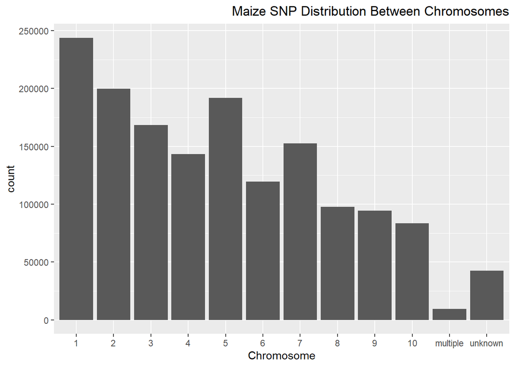

```r
merged_data <- arrange(merged_data, `Position`)
maize_merged_data <- pivot_longer(
  merged_data,
  cols = 4:ncol(merged_data),
  values_to = "SNP"
)

proper_chromosome_order <- c(
  "1", "2", "3", "4", "5", "6", "7", "8", "9", "10", "multiple", "unknown"
)
ggplot(data = maize_merged_data) + geom_bar(mapping = aes(x=Chromosome)) +
scale_x_discrete(limits = proper_chromosome_order)+
ggtitle("Maize SNP Distribution Between Chromosomes")+
theme(plot.title = element_text(hjust = 1))
```

Load teosinte data.

```r
# Teosinte data.
extracted_data <- filter(data, `Group` %in% c("ZMPBA", "ZMPIL", "ZMPJA"))
extracted_data <- arrange(extracted_data, `Sample_ID`)
transposed_data <- as_tibble(t(extracted_data[,4:ncol(extracted_data)]),rownames = "SNP_ID")
colnames(transposed_data) <- c("SNP_ID",unlist(extracted_data[1:nrow(extracted_data),1]), use.names = FALSE)
snp_data = read_delim("snp_position.txt", "\t")
merged_data <- merge(snp_data[,c(1,3,4)], transposed_data, by="SNP_ID", all = TRUE)
merged_data <- as_tibble(merged_data)
merged_data$Position <- as.numeric(merged_data$Position)
```

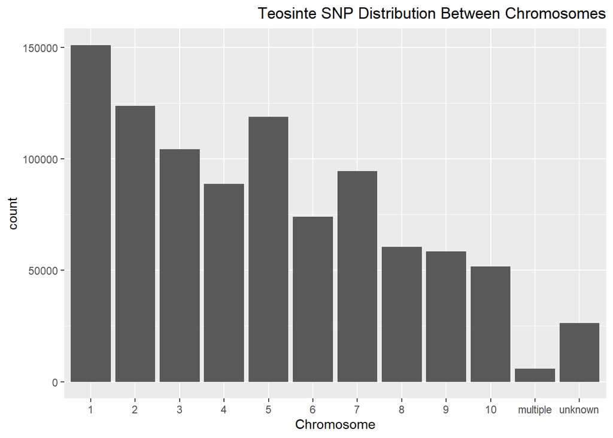

```r
merged_data <- arrange(merged_data, `Position`)
teosinte_merged_data <- pivot_longer(
  merged_data,
  cols = 4:ncol(merged_data),
  values_to = "SNP"
)

proper_chromosome_order <- c(
  "1", "2", "3", "4", "5", "6", "7", "8", "9", "10", "multiple", "unknown"
)
ggplot(data = teosinte_merged_data) + geom_bar(mapping = aes(x=Chromosome)) +
scale_x_discrete(limits = proper_chromosome_order) +
ggtitle("Teosinte SNP Distribution Between Chromosomes")+
theme(plot.title = element_text(hjust = 1))
```

Observation: Based on the data, it appears that both maize and teosinte have a similar distribution of SNPs across chromosomes. However, maize has a higher number of SNPs per position, as indicated by the larger number of columns in the dataframe (1576 for maize compared to 978 for teosinte).

Distribution of SNPs (# of SNPs)

Load maize data.

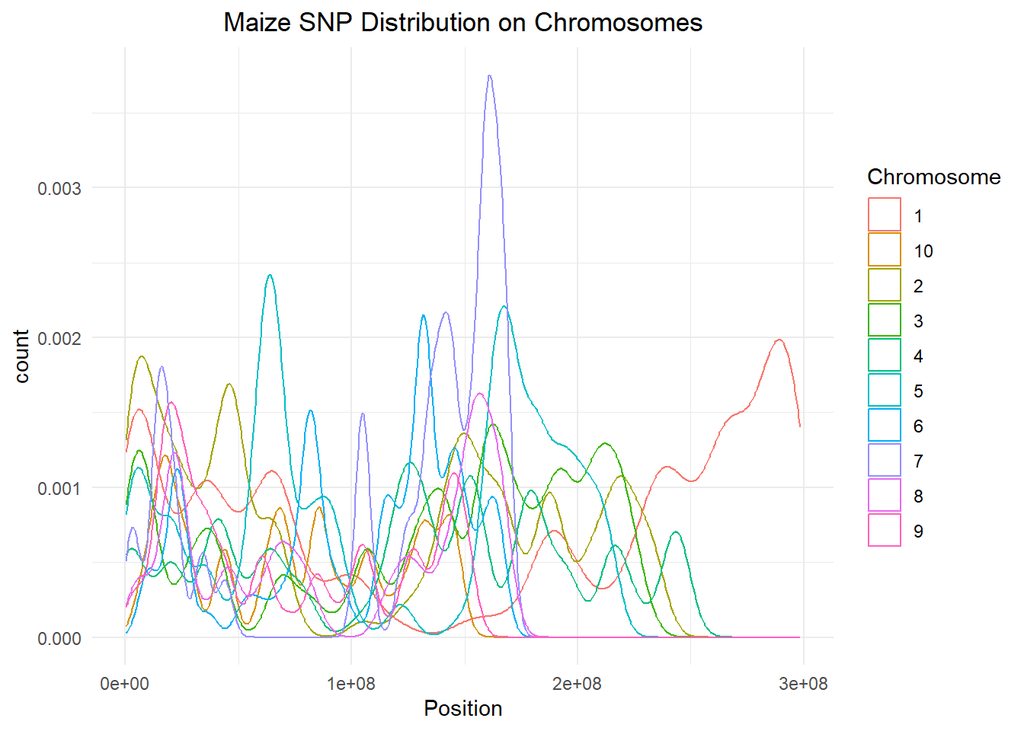

```r
ggplot(data = maize_merged_data) +
  geom_density(aes(x=Position, color=Chromosome,y = after_stat(count))) +
  theme_minimal()+
  ggtitle("Maize SNP Distribution on Chromosomes")+
  theme(plot.title = element_text(hjust = 0.5))
```

Load teosinte data.

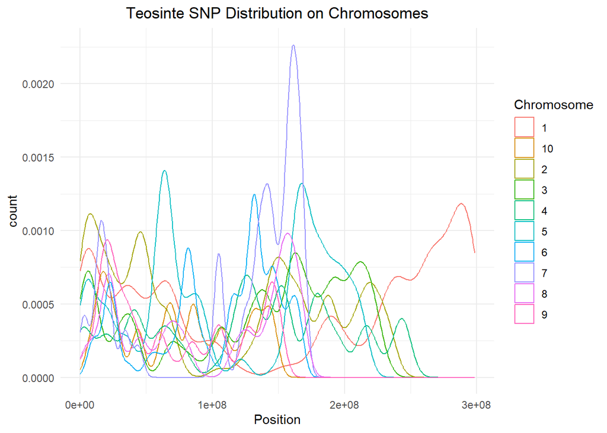

```r
ggplot(data = teosinte_merged_data) +
  geom_density(aes(x=Position, color=Chromosome,y = after_stat(count))) +
  theme_minimal()+
  ggtitle("Teosinte SNP Distribution on Chromosomes")+
  theme(plot.title = element_text(hjust = 0.5))
```

Observation: The data suggests that the distributions of SNPs are similar between maize and teosinte, which is expected since their SNP positions are identical. Notable observations include chromosome 7, where the SNP positions are more concentrated in the middle, and chromosome 1, which shows a bimodal distribution with a higher concentration of SNPs at both ends.

Conclusion: Based on the analysis, we can conclude that while maize and teosinte share similar SNP distributions across chromosomes, there are some distinct patterns worth noting. Chromosome 7 exhibits a concentration of SNPs in the middle, possibly indicating a unique region of interest in both species. Meanwhile, chromosome 1 shows a bimodal distribution with SNPs concentrated at the ends, suggesting a potential structural or functional distinction at these loci. Overall, these distribution patterns provide valuable insights into the genomic differences and similarities between maize and teosinte, potentially guiding further studies into their evolutionary or functional significance.

### Missing data and amount of heterozygosiity

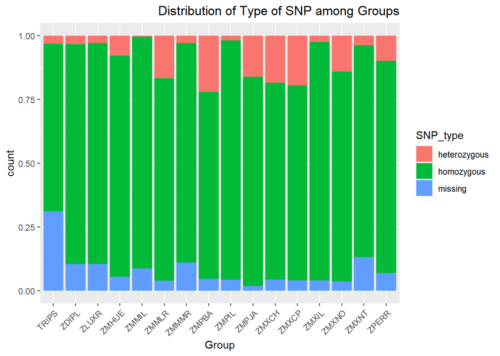

```r
# data
data_long <- pivot_longer(data, cols = 4:ncol(data), values_to = "SNP")
# type of SNPs
find_snp_type <- function(SNP){
  SNP_string <- toString(SNP)
  SNP_positions <- strsplit(SNP_string,split="")
  position_1 <- SNP_positions[[1]][1]
  position_2 <- SNP_positions[[1]][3]
  if (position_1 == "?" | position_2 == "?"){
    return("missing")
  }
  else if (position_1 == position_2){
    return("homozygous")
  }
  else if (position_1 != position_2){
    return("heterozygous")
  }
}
vectorized_find <- Vectorize(find_snp_type)
data_long <- mutate(data_long, SNP_type = vectorized_find(SNP))
# ggplot
ggplot(data = data_long) +
  geom_bar(mapping = aes(x = Group, fill = SNP_type), position = "fill")+
  ggtitle("Distribution of Type of SNP among Groups")+
  theme(plot.title = element_text(hjust = 1))+
  theme(axis.text.x=element_text(angle=45,hjust=1))
```

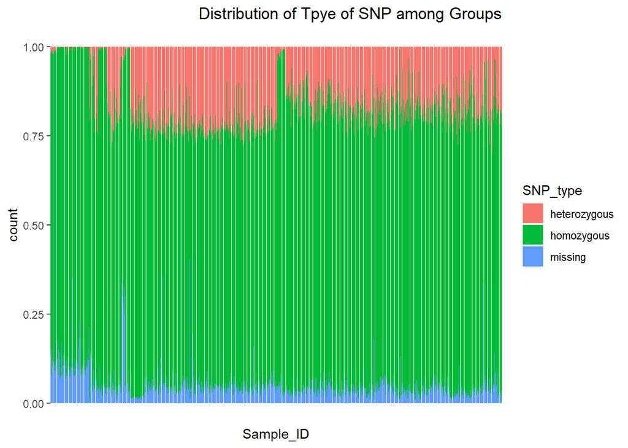

```r
ggplot(data = data_long) +
  geom_bar(mapping = aes(x = Sample_ID, fill = SNP_type), position = "fill")+
  ggtitle("Distribution of Tpye of SNP among Groups")+
  theme(plot.title = element_text(hjust = 1))+
  theme(axis.text.x = element_blank(), axis.ticks.x = element_blank(), axis.line.x = element_blank())
```

Observation: Based on the data, the proportions of heterozygosity, homozygosity, and missing data are relatively consistent across groups and samples. However, there are notable outliers: TRIPS, which shows a higher proportion of missing data, and ZMMIL, which has an exceptionally low number of heterozygous SNPs. These outliers may warrant further investigation to understand the underlying causes and their potential implications for the analysis.